# bfd

Autogenerated data summary from dataMaid

2022-07-22 01:21:48

# Data report overview

The dataset examined has the following dimensions:

| Feature | Result |
| --- | --- |
| Number of observations | 801963 |
| Number of variables | 49 |

### Checks performed

The following variable checks were performed, depending on the data type of each variable:

|  | character | factor | labelled | haven labelled | numeric | integer | logical | Date |
| --- | --- | --- | --- | --- | --- | --- | --- | --- |
| Identify miscoded missing values | × | × | × | × | × | × |  | × |
| Identify prefixed and suffixed whitespace | × | × | × | × |  |  |  |  |
| Identify levels with < 6 obs. | × | × | × | × |  |  |  |  |
| Identify case issues | × | × | × | × |  |  |  |  |
| Identify misclassified numeric or integer variables | × | × | × | × |  |  |  |  |
| Identify outliers |  |  |  |  | × | × |  | × |

Please note that all numerical values in the following have been rounded to 2 decimals.

# Summary table

|  | Variable class | # unique values | Missing observations | Any problems? |
| --- | --- | --- | --- | --- |
| flight_id | factor | 6514 | 0.00 % | × |
| airline_icao | factor | 70 | 0.00 % | × |
| airline_name | factor | 1 | 0.00 % | × |
| linetype_code | factor | 9 | 0.01 % |  |
| origin_icao | factor | 246 | 0.00 % | × |
| origin_name | factor | 1 | 0.00 % | × |
| origin_country | factor | 1 | 0.00 % | × |
| expected_depart_date | factor | 366 | 0.00 % | × |
| expected_depart_hour | factor | 24 | 0.00 % | × |
| real_depart_date | factor | 367 | 0.00 % | × |
| real_depart_hour | factor | 24 | 0.00 % | × |
| expected_duration | numeric | 711 | 0.00 % | × |
| departure_delay | numeric | 1403 | 0.00 % | × |
| depart_temperature | numeric | 42 | 0.00 % | × |
| depart_dew_point | numeric | 42 | 0.00 % | × |
| depart_humidity | numeric | 729 | 0.00 % | × |
| depart_pressure | numeric | 1 | 0.00 % | × |
| depart_visibility | numeric | 64 | 10.18 % | × |
| depart_cloudiness | numeric | 1 | 100.00 % | × |
| depart_ceiling | numeric | 61 | 38.49 % | × |
| depart_wind_speed | numeric | 38 | 0.00 % | × |
| ds_depart_wind_speed | ordered | 12 | 0.00 % | × |
| depart_wind_direction | numeric | 40 | 12.02 % |  |
| ds_depart_wind_direction | factor | 17 | 0.00 % |  |
| ds_depart_day_period | ordered | 7 | 0.00 % |  |
| destination_icao | factor | 257 | 0.00 % | × |
| destination_name | factor | 1 | 0.00 % | × |
| destination_country | factor | 1 | 0.00 % | × |
| expected_arrival_date | factor | 366 | 0.00 % | × |
| expected_arrival_hour | factor | 24 | 0.00 % | × |
| real_arrival_date | factor | 367 | 0.00 % | × |
| real_arrival_hour | factor | 24 | 0.00 % | × |
| real_duration | numeric | 736 | 0.00 % | × |
| arrival_delay | numeric | 1446 | 0.00 % | × |
| arrival_temperature | numeric | 42 | 0.00 % | × |
| arrival_dew_point | numeric | 41 | 0.00 % | × |
| arrival_humidity | numeric | 725 | 0.00 % | × |
| arrival_pressure | numeric | 1 | 0.00 % | × |
| arrival_visibility | numeric | 64 | 10.28 % | × |
| arrival_cloudiness | factor | 8 | 35.75 % | × |
| arrival_ceiling | numeric | 67 | 38.59 % | × |
| arrival_wind_speed | numeric | 41 | 0.00 % | × |
| ds_arrival_wind_speed | ordered | 13 | 0.00 % | × |
| arrival_wind_direction | numeric | 40 | 12.13 % | × |
| ds_arrival_wind_direction | factor | 17 | 0.00 % |  |
| ds_arrival_day_period | ordered | 7 | 0.00 % |  |
| situation_type | factor | 1 | 0.00 % | × |
| justification_code | factor | 36 | 0.00 % | × |
| justification_description | factor | 1 | 0.00 % | × |

# Variable list

## flight_id

| Feature | Result |
| --- | --- |
| Variable type | factor |
| Number of missing obs. | 0 (0 %) |
| Number of unique values | 6514 |
| Mode | “2268” |
| Reference category | 0002 |

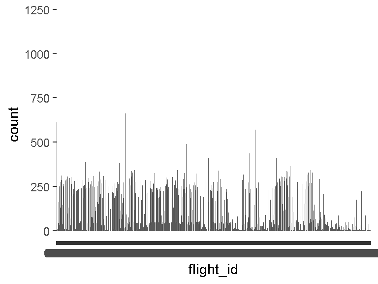

- The following suspected missing value codes enter as regular values: "9999".
- Note that the following levels have at most five observations: "0006", "0023", "0034", "0208", "0282", …, "Z9063", "Z9080", "Z9086", "Z9256", "Z9274" (762 values omitted).

## airline_icao

| Feature | Result |
| --- | --- |
| Variable type | factor |
| Number of missing obs. | 0 (0 %) |
| Number of unique values | 70 |
| Mode | “AZU” |
| Reference category | AAL |

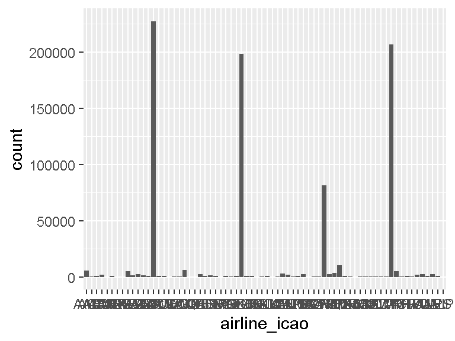

- Note that the following levels have at most five observations: "KYE", "MAA", "VIP".

## airline_name

- The variable only takes one (non-missing) value: "nm_aerodromo_destino". The variable contains 0 % missing observations.

## linetype_code

| Feature | Result |
| --- | --- |
| Variable type | factor |
| Number of missing obs. | 116 (0.01 %) |
| Number of unique values | 8 |
| Mode | “N” |
| Reference category | C |

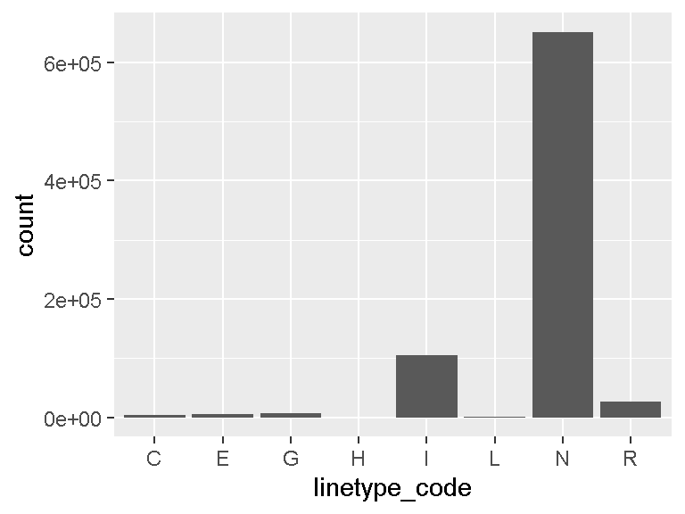

## origin_icao

| Feature | Result |
| --- | --- |
| Variable type | factor |
| Number of missing obs. | 0 (0 %) |
| Number of unique values | 246 |
| Mode | “SBGR” |
| Reference category | CYYZ |

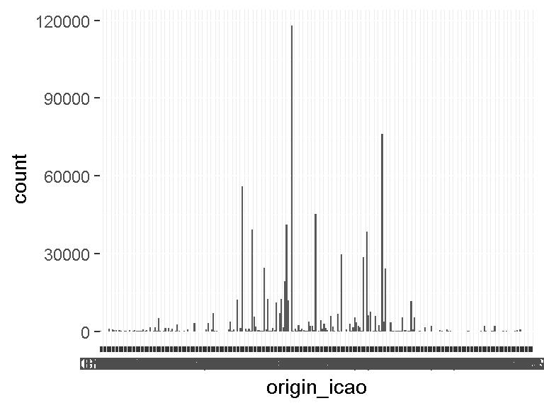

- Note that the following levels have at most five observations: "DIAP", "EBBR", "EDDM", "GCLP", "GVNP", …, "SSZR", "SWYN", "TJSJ", "TNCA", "TTPP" (26 values omitted).

## origin_name

- The variable only takes one (non-missing) value: "nm_aerodromo_origem". The variable contains 0 % missing observations.

## origin_country

- The variable only takes one (non-missing) value: "nm_aerodromo_destino". The variable contains 0 % missing observations.

## expected_depart_date

| Feature | Result |
| --- | --- |
| Variable type | factor |
| Number of missing obs. | 0 (0 %) |
| Number of unique values | 366 |
| Mode | “20180716” |
| Reference category | 20180101 |

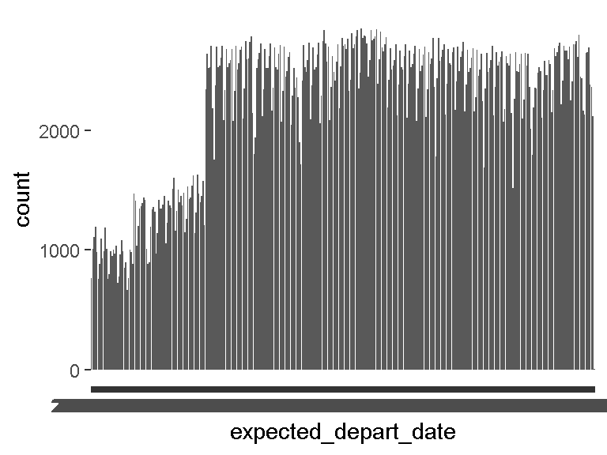

- Note: The variable consists exclusively of numbers and takes a lot of different values. Is it perhaps a misclassified numeric variable?

## expected_depart_hour

| Feature | Result |
| --- | --- |
| Variable type | factor |
| Number of missing obs. | 0 (0 %) |
| Number of unique values | 24 |
| Mode | “15” |
| Reference category | 00 |

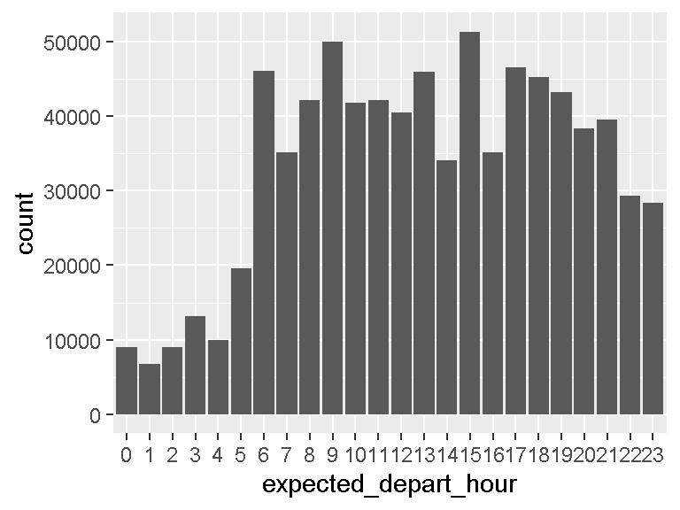

- Note: The variable consists exclusively of numbers and takes a lot of different values. Is it perhaps a misclassified numeric variable?

## real_depart_date

| Feature | Result |
| --- | --- |
| Variable type | factor |
| Number of missing obs. | 0 (0 %) |
| Number of unique values | 367 |
| Mode | “20180716” |
| Reference category | 20170808 |

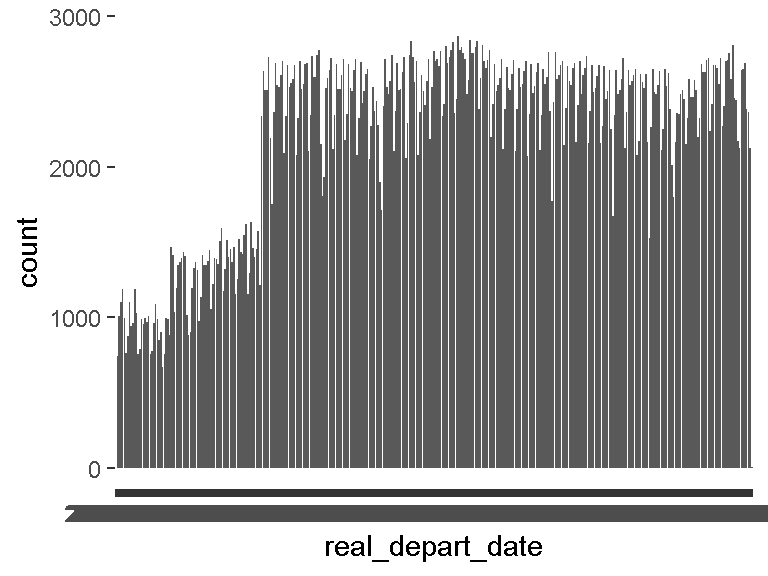

- Note that the following levels have at most five observations: "20170808".
- Note: The variable consists exclusively of numbers and takes a lot of different values. Is it perhaps a misclassified numeric variable?

## real_depart_hour

| Feature | Result |
| --- | --- |
| Variable type | factor |
| Number of missing obs. | 0 (0 %) |
| Number of unique values | 24 |
| Mode | “15” |
| Reference category | 00 |

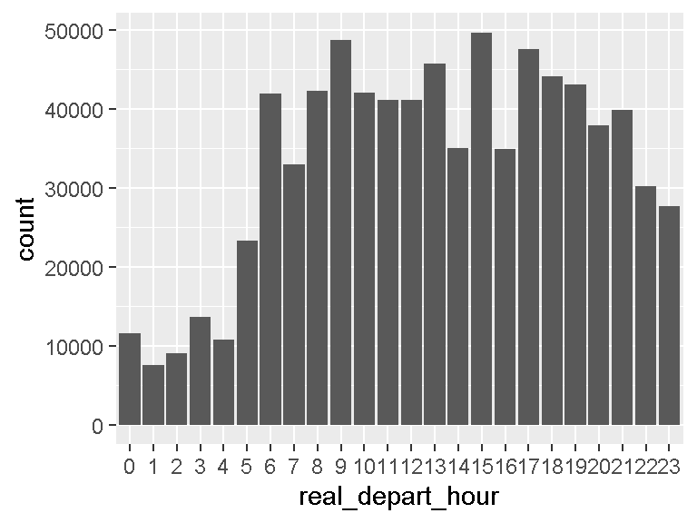

- Note: The variable consists exclusively of numbers and takes a lot of different values. Is it perhaps a misclassified numeric variable?

## expected_duration

| Feature | Result |
| --- | --- |
| Variable type | numeric |
| Number of missing obs. | 0 (0 %) |
| Number of unique values | 711 |
| Median | 100 |
| 1st and 3rd quartiles | 75; 160 |
| Min. and max. | 14; 835 |

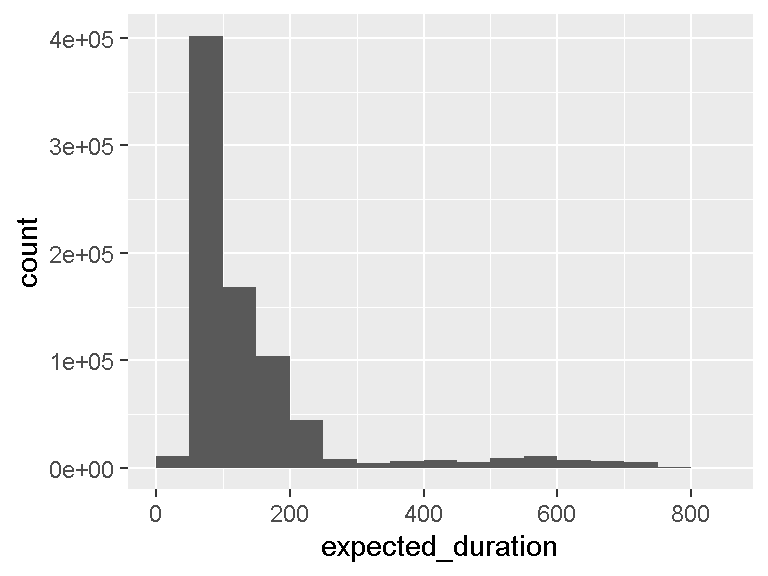

- Note that the following possible outlier values were detected: "14", "25", "30", "31", "33", …, "775", "780", "790", "820", "835" (155 values omitted).

## departure_delay

| Feature | Result |
| --- | --- |
| Variable type | numeric |
| Number of missing obs. | 0 (0 %) |
| Number of unique values | 1403 |
| Median | 0 |
| 1st and 3rd quartiles | -4; 6 |
| Min. and max. | -525576; 1439 |

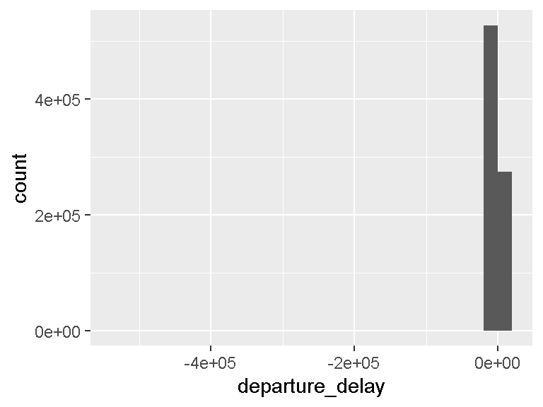

- Note that the following possible outlier values were detected: "-525576", "-437772", "-87850", "-44668", "-44643", …, "1435", "1436", "1437", "1438", "1439" (1332 values omitted).

## depart_temperature

| Feature | Result |
| --- | --- |
| Variable type | numeric |
| Number of missing obs. | 0 (0 %) |
| Number of unique values | 42 |
| Median | 24 |
| 1st and 3rd quartiles | 20; 26 |
| Min. and max. | 0; 40 |

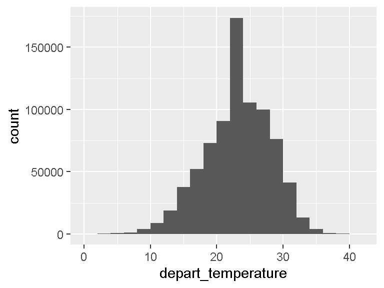

- Note that the following possible outlier values were detected: "29", "30", "31", "32", "33", …, "36", "37", "38", "39", "40" (2 values omitted).

## depart_dew_point

| Feature | Result |
| --- | --- |
| Variable type | numeric |
| Number of missing obs. | 0 (0 %) |
| Number of unique values | 42 |
| Median | 18 |
| 1st and 3rd quartiles | 15; 22 |
| Min. and max. | -9; 36 |

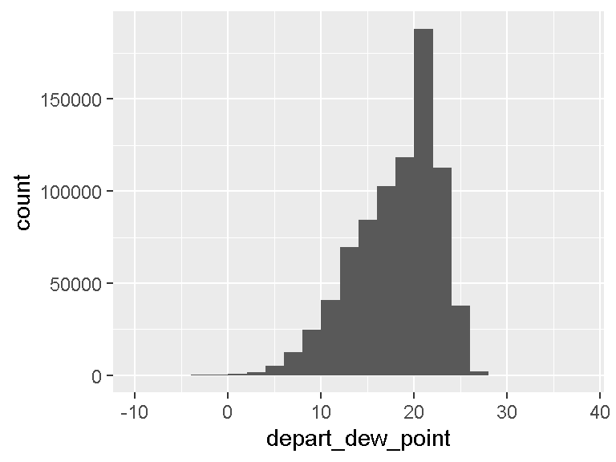

- Note that the following possible outlier values were detected: "-9", "-6", "-5", "-4", "-3", …, "1", "30", "31", "33", "36" (3 values omitted).

## depart_humidity

| Feature | Result |
| --- | --- |
| Variable type | numeric |
| Number of missing obs. | 0 (0 %) |
| Number of unique values | 729 |
| Median | 73.78 |
| 1st and 3rd quartiles | 65.12; 88.09 |
| Min. and max. | 7; 100 |

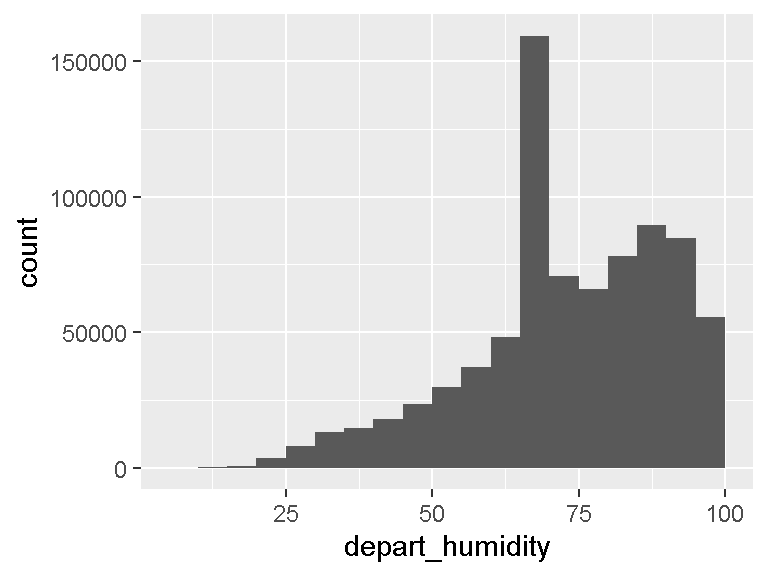

- Note that the following possible outlier values were detected: "7", "7.39", "7.53", "8.56", "9.04", …, "40.85", "40.96", "41.13", "41.14", "41.23" (353 values omitted).

## depart_pressure

- The variable only takes one (non-missing) value: "1015". The variable contains 0 % missing observations.

## depart_visibility

| Feature | Result |
| --- | --- |
| Variable type | numeric |
| Number of missing obs. | 81637 (10.18 %) |
| Number of unique values | 63 |
| Median | 6.21 |
| 1st and 3rd quartiles | 6.21; 6.21 |
| Min. and max. | 0.03; 6.21 |

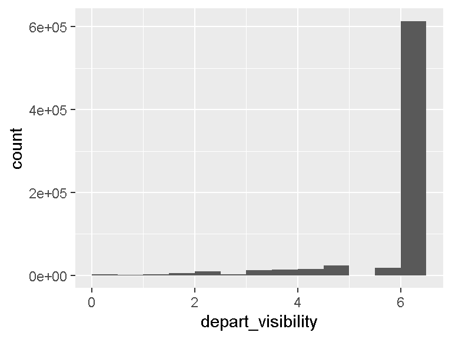

- Note that the following possible outlier values were detected: "0.03", "0.06", "0.09", "0.12", "0.16", …, "3.11", "3.73", "4.35", "4.97", "5.59" (52 values omitted).

## depart_cloudiness

- The variable only takes one value: "NA".

## depart_ceiling

| Feature | Result |
| --- | --- |
| Variable type | numeric |
| Number of missing obs. | 308696 (38.49 %) |
| Number of unique values | 60 |
| Median | 2000 |
| 1st and 3rd quartiles | 1200; 3000 |
| Min. and max. | 0; 10000 |

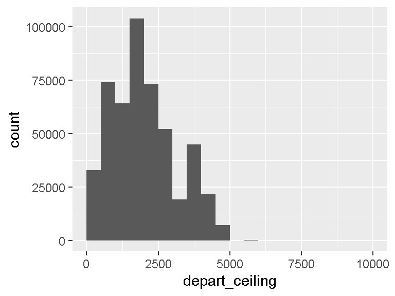

- Note that the following possible outlier values were detected: "8000", "8500", "9000", "10000".

## depart_wind_speed

| Feature | Result |
| --- | --- |
| Variable type | numeric |
| Number of missing obs. | 0 (0 %) |
| Number of unique values | 38 |
| Median | 6 |
| 1st and 3rd quartiles | 4; 8 |
| Min. and max. | 0; 109 |

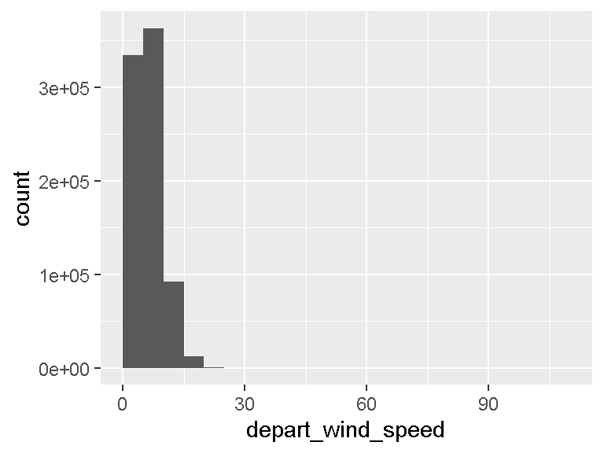

- Note that the following possible outlier values were detected: "16", "17", "18", "19", "20", …, "39", "40", "50", "63", "109" (11 values omitted).

## ds_depart_wind_speed

| Feature | Result |
| --- | --- |
| Variable type | ordered |
| Number of missing obs. | 0 (0 %) |
| Number of unique values | 12 |
| Mode | “Light Breeze” |
| Reference category | Calm |

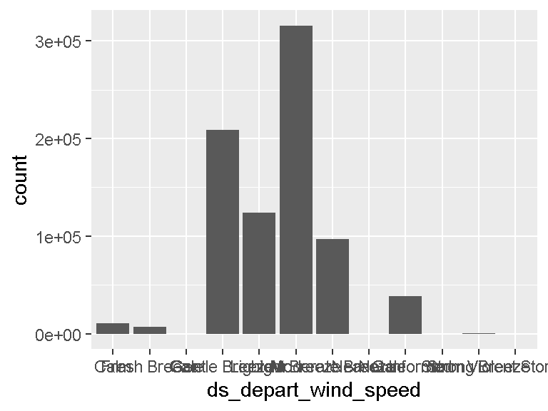

- Note that the following levels have at most five observations: "Storm", "Violent Storm".

## depart_wind_direction

| Feature | Result |
| --- | --- |
| Variable type | numeric |
| Number of missing obs. | 96434 (12.02 %) |
| Number of unique values | 39 |
| Median | 120 |
| 1st and 3rd quartiles | 70; 190 |
| Min. and max. | 0; 360 |

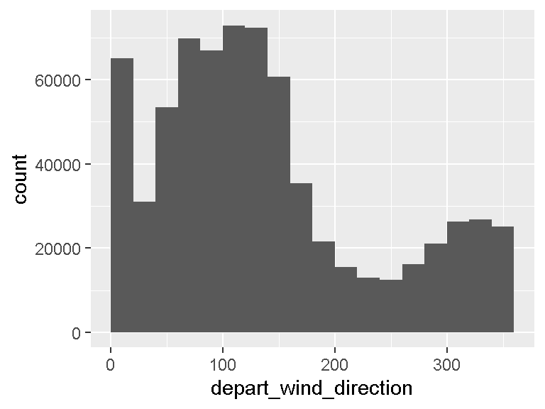

## ds_depart_wind_direction

| Feature | Result |
| --- | --- |
| Variable type | factor |
| Number of missing obs. | 0 (0 %) |
| Number of unique values | 17 |
| Mode | “Not Informed” |
| Reference category | E |

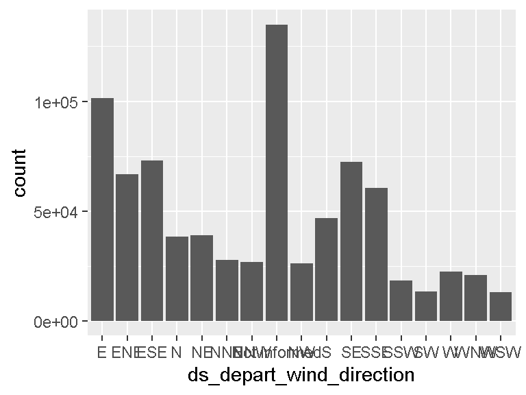

## ds_depart_day_period

| Feature | Result |
| --- | --- |
| Variable type | ordered |
| Number of missing obs. | 0 (0 %) |
| Number of unique values | 7 |
| Mode | “Afternoon” |
| Reference category | Night |

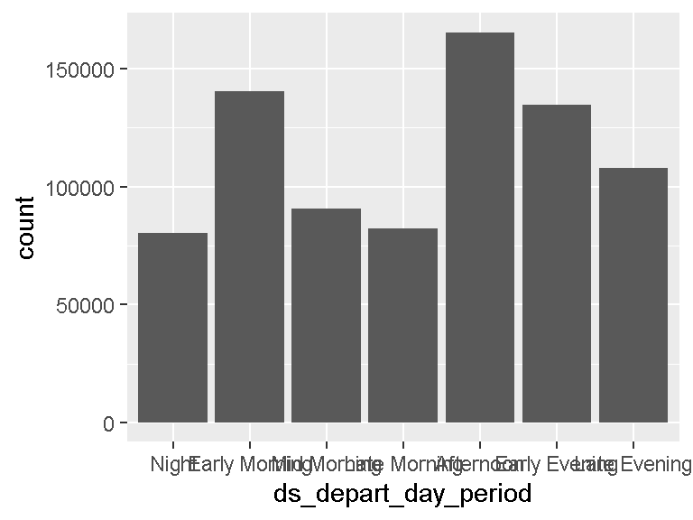

## destination_icao

| Feature | Result |
| --- | --- |
| Variable type | factor |
| Number of missing obs. | 0 (0 %) |
| Number of unique values | 257 |
| Mode | “SBGR” |
| Reference category | CYYZ |

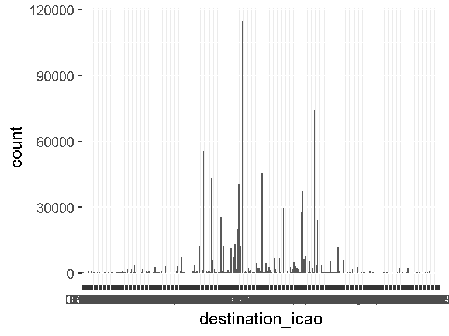

- Note that the following levels have at most five observations: "DNMM", "EDDM", "EGNX", "GABS", "GCLP", …, "SPSO", "SUPE", "TJSJ", "TNCA", "TTPP" (34 values omitted).

## destination_name

- The variable only takes one (non-missing) value: "nm_aerodromo_destino". The variable contains 0 % missing observations.

## destination_country

- The variable only takes one (non-missing) value: "nm_aerodromo_destino". The variable contains 0 % missing observations.

## expected_arrival_date

| Feature | Result |
| --- | --- |
| Variable type | factor |
| Number of missing obs. | 0 (0 %) |
| Number of unique values | 366 |
| Mode | “20180716” |
| Reference category | 20180101 |

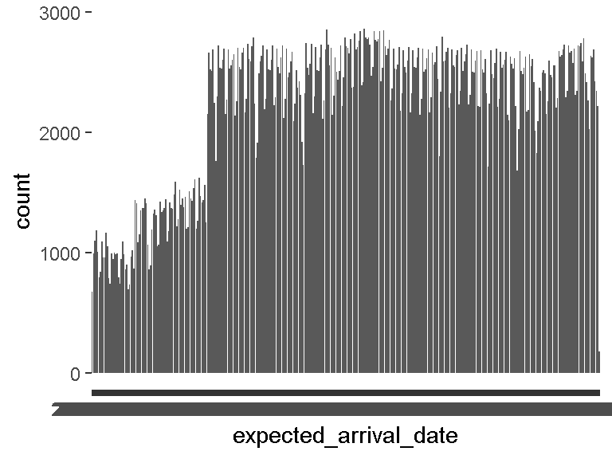

- Note: The variable consists exclusively of numbers and takes a lot of different values. Is it perhaps a misclassified numeric variable?

## expected_arrival_hour

| Feature | Result |
| --- | --- |
| Variable type | factor |
| Number of missing obs. | 0 (0 %) |
| Number of unique values | 24 |
| Mode | “16” |
| Reference category | 00 |

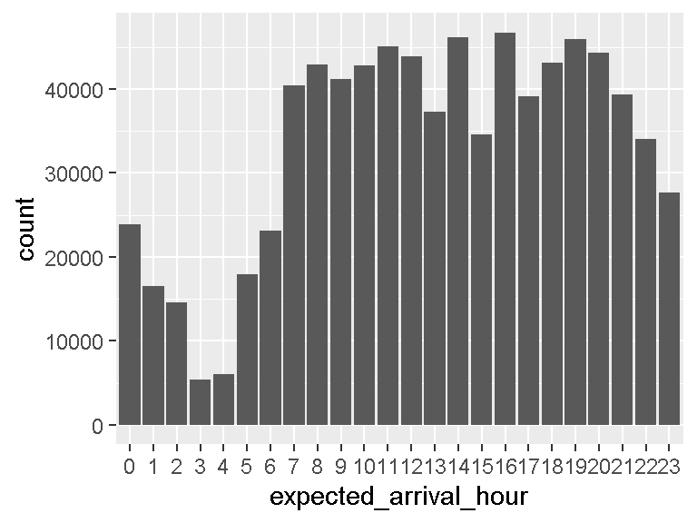

- Note: The variable consists exclusively of numbers and takes a lot of different values. Is it perhaps a misclassified numeric variable?

## real_arrival_date

| Feature | Result |
| --- | --- |
| Variable type | factor |
| Number of missing obs. | 0 (0 %) |
| Number of unique values | 367 |
| Mode | “20180716” |
| Reference category | 20170809 |

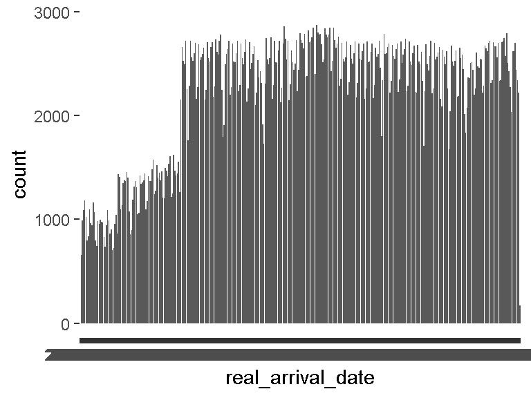

- Note that the following levels have at most five observations: "20170809".
- Note: The variable consists exclusively of numbers and takes a lot of different values. Is it perhaps a misclassified numeric variable?

## real_arrival_hour

| Feature | Result |
| --- | --- |
| Variable type | factor |
| Number of missing obs. | 0 (0 %) |
| Number of unique values | 24 |
| Mode | “14” |
| Reference category | 00 |

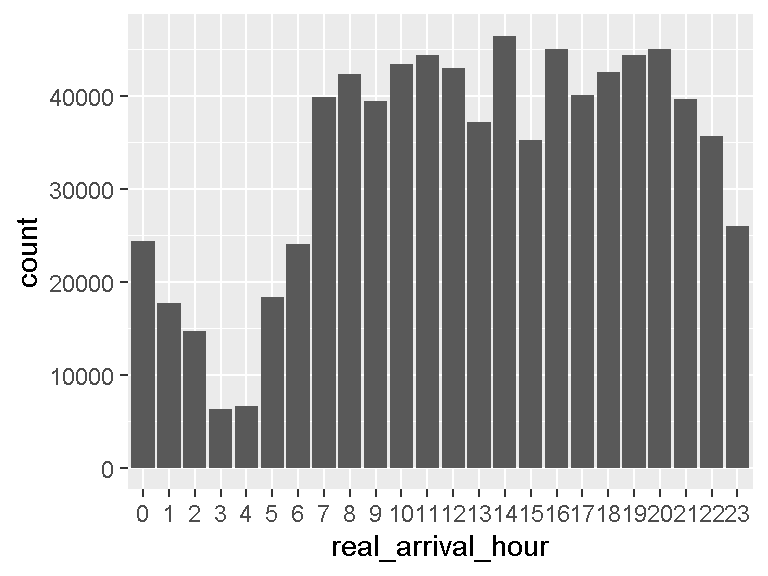

- Note: The variable consists exclusively of numbers and takes a lot of different values. Is it perhaps a misclassified numeric variable?

## real_duration

| Feature | Result |
| --- | --- |
| Variable type | numeric |
| Number of missing obs. | 0 (0 %) |
| Number of unique values | 736 |
| Median | 98 |
| 1st and 3rd quartiles | 71; 158 |
| Min. and max. | 45; 780 |

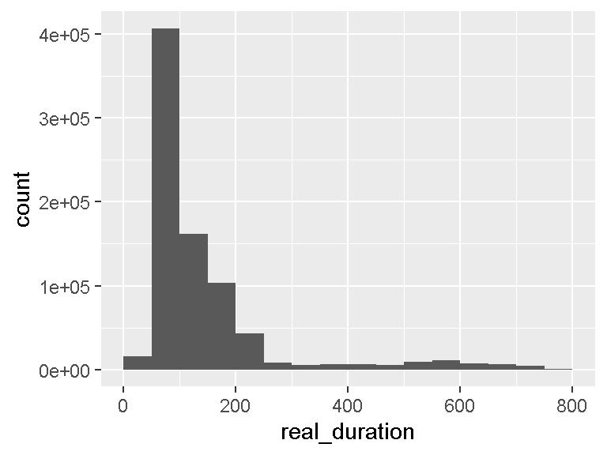

- Note that the following possible outlier values were detected: "45", "46", "47", "628", "629", …, "776", "777", "778", "779", "780" (146 values omitted).

## arrival_delay

| Feature | Result |
| --- | --- |
| Variable type | numeric |
| Number of missing obs. | 0 (0 %) |
| Number of unique values | 1446 |
| Median | 0 |
| 1st and 3rd quartiles | -9; 6 |
| Min. and max. | -525610; 1439 |

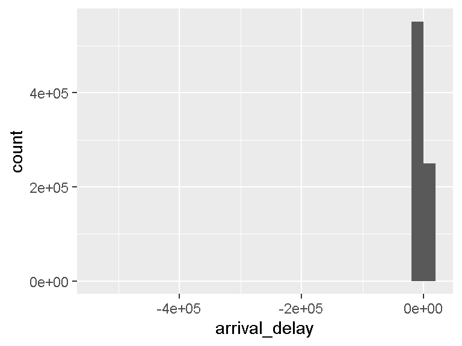

- Note that the following possible outlier values were detected: "-525610", "-437788", "-87826", "-44692", "-44681", …, "1435", "1436", "1437", "1438", "1439" (1375 values omitted).

## arrival_temperature

| Feature | Result |
| --- | --- |
| Variable type | numeric |
| Number of missing obs. | 0 (0 %) |
| Number of unique values | 42 |
| Median | 22 |
| 1st and 3rd quartiles | 20; 26 |
| Min. and max. | 0; 40 |

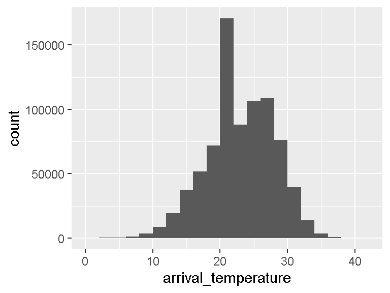

- Note that the following possible outlier values were detected: "0", "1", "2", "3", "4", …, "11", "12", "13", "14", "15" (6 values omitted).

## arrival_dew_point

| Feature | Result |
| --- | --- |
| Variable type | numeric |
| Number of missing obs. | 0 (0 %) |
| Number of unique values | 41 |
| Median | 18 |
| 1st and 3rd quartiles | 15; 22 |
| Min. and max. | -6; 36 |

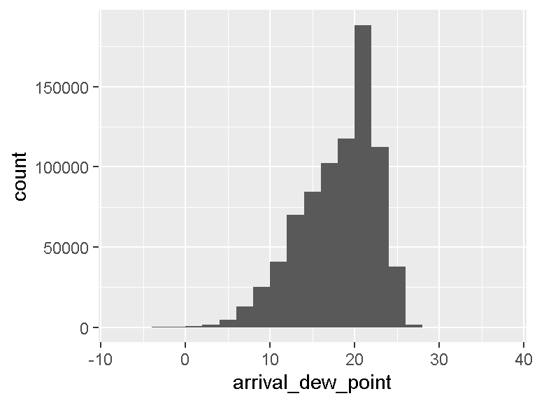

- Note that the following possible outlier values were detected: "-6", "-5", "-4", "-3", "-2", …, "1", "30", "31", "34", "36" (2 values omitted).

## arrival_humidity

| Feature | Result |
| --- | --- |
| Variable type | numeric |
| Number of missing obs. | 0 (0 %) |
| Number of unique values | 725 |
| Median | 73.78 |
| 1st and 3rd quartiles | 65.12; 88 |
| Min. and max. | 7; 100 |

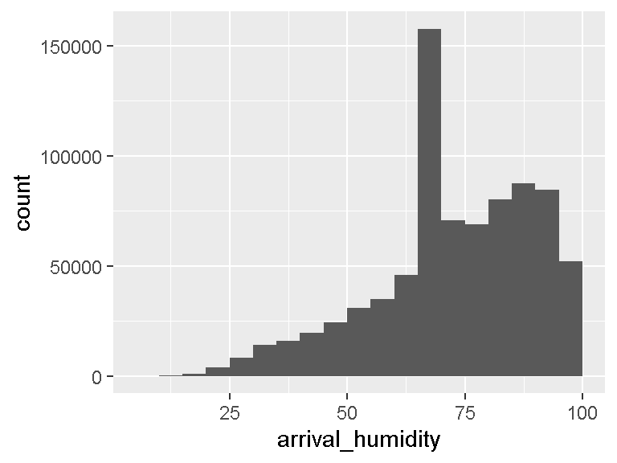

- Note that the following possible outlier values were detected: "7", "7.39", "8.56", "9.04", "9.21", …, "39.27", "39.3", "39.43", "39.54", "39.58" (333 values omitted).

## arrival_pressure

- The variable only takes one (non-missing) value: "1015". The variable contains 0 % missing observations.

## arrival_visibility

| Feature | Result |
| --- | --- |
| Variable type | numeric |
| Number of missing obs. | 82448 (10.28 %) |
| Number of unique values | 63 |
| Median | 6.21 |
| 1st and 3rd quartiles | 6.21; 6.21 |
| Min. and max. | 0; 6.21 |

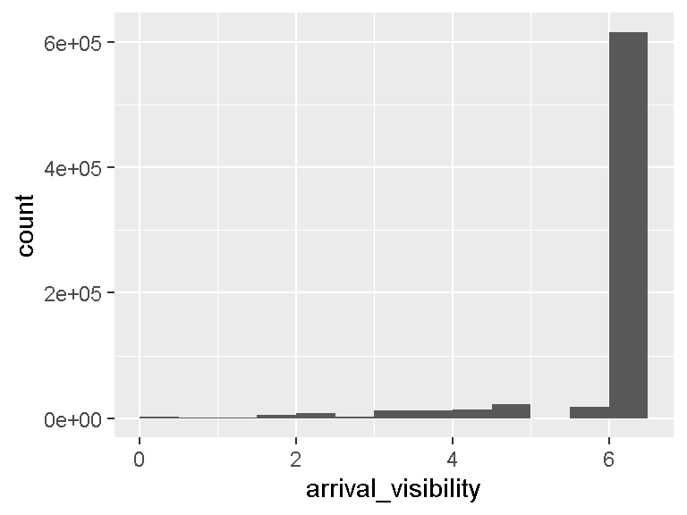

- Note that the following possible outlier values were detected: "0", "0.03", "0.06", "0.09", "0.12", …, "3.11", "3.73", "4.35", "4.97", "5.59" (52 values omitted).

## arrival_cloudiness

| Feature | Result |
| --- | --- |
| Variable type | factor |
| Number of missing obs. | 286715 (35.75 %) |
| Number of unique values | 7 |
| Mode | “FEW” |
| Reference category | BKN |

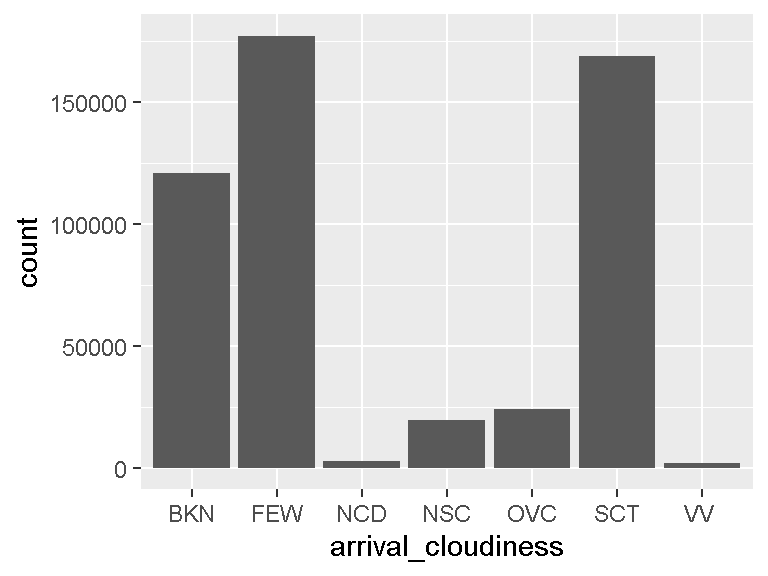

- The following values appear with prefixed or suffixed white space: "VV ".

## arrival_ceiling

| Feature | Result |
| --- | --- |
| Variable type | numeric |
| Number of missing obs. | 309467 (38.59 %) |
| Number of unique values | 66 |
| Median | 2000 |
| 1st and 3rd quartiles | 1300; 3000 |
| Min. and max. | 0; 15000 |

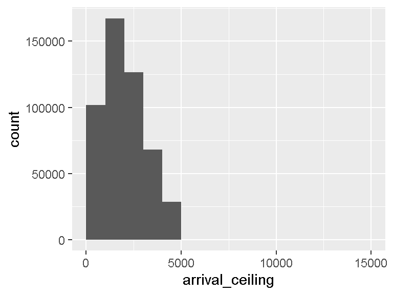

- Note that the following possible outlier values were detected: "7500", "7600", "8000", "8200", "8500", "9000", "10000", "11000", "15000".

## arrival_wind_speed

| Feature | Result |
| --- | --- |
| Variable type | numeric |
| Number of missing obs. | 0 (0 %) |
| Number of unique values | 41 |
| Median | 6 |
| 1st and 3rd quartiles | 4; 8 |
| Min. and max. | 0; 69 |

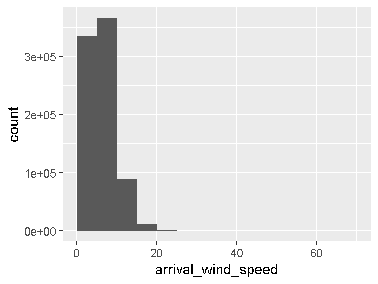

- Note that the following possible outlier values were detected: "15", "16", "17", "18", "19", …, "39", "40", "50", "63", "69" (15 values omitted).

## ds_arrival_wind_speed

| Feature | Result |
| --- | --- |
| Variable type | ordered |
| Number of missing obs. | 0 (0 %) |
| Number of unique values | 13 |
| Mode | “Light Breeze” |
| Reference category | Calm |

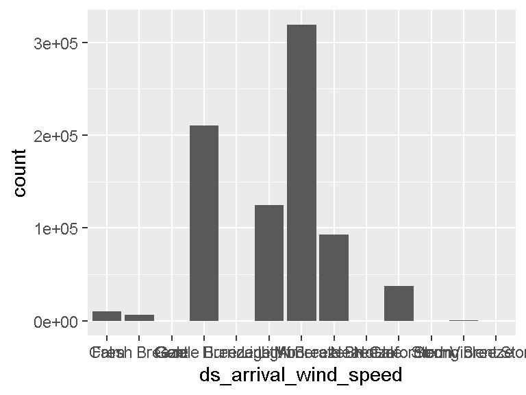

- Note that the following levels have at most five observations: "Hurricane", "Storm", "Violent Storm".

## arrival_wind_direction

| Feature | Result |
| --- | --- |
| Variable type | numeric |
| Number of missing obs. | 97252 (12.13 %) |
| Number of unique values | 39 |
| Median | 120 |
| 1st and 3rd quartiles | 70; 190 |
| Min. and max. | 0; 360 |

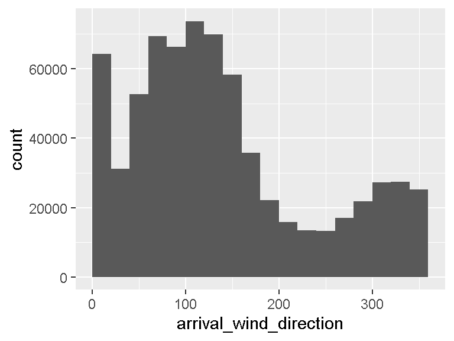

- Note that the following possible outlier values were detected: "0".

## ds_arrival_wind_direction

| Feature | Result |
| --- | --- |
| Variable type | factor |
| Number of missing obs. | 0 (0 %) |
| Number of unique values | 17 |
| Mode | “Not Informed” |
| Reference category | E |

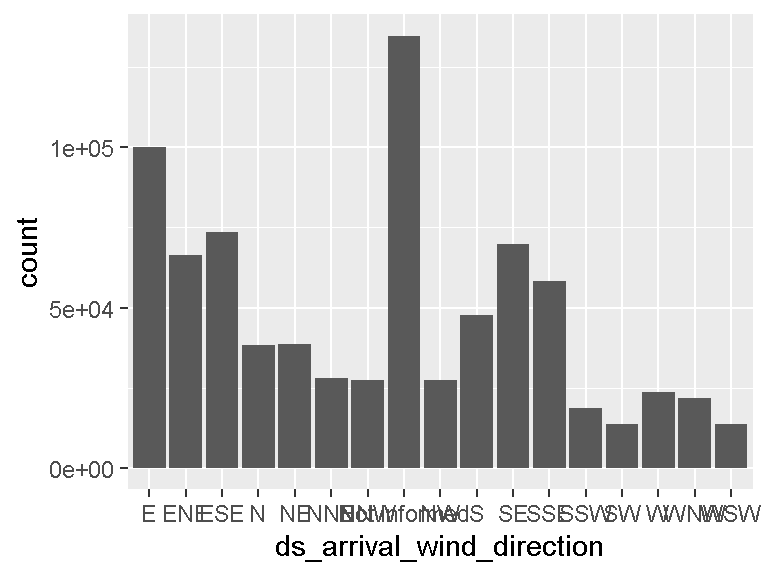

## ds_arrival_day_period

| Feature | Result |
| --- | --- |
| Variable type | ordered |
| Number of missing obs. | 0 (0 %) |
| Number of unique values | 7 |
| Mode | “Afternoon” |
| Reference category | Night |

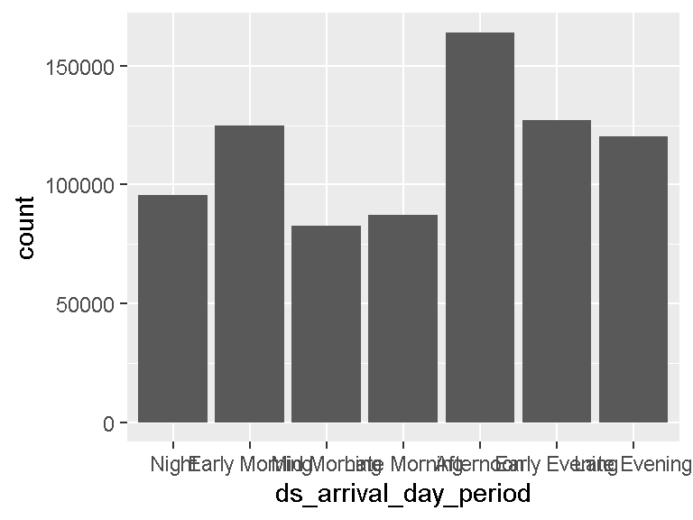

## situation_type

- The variable only takes one (non-missing) value: "REALIZADO". The variable contains 0 % missing observations.

## justification_code

| Feature | Result |
| --- | --- |
| Variable type | factor |
| Number of missing obs. | 0 (0 %) |
| Number of unique values | 36 |
| Mode | “N/A” |
| Reference category | AF |

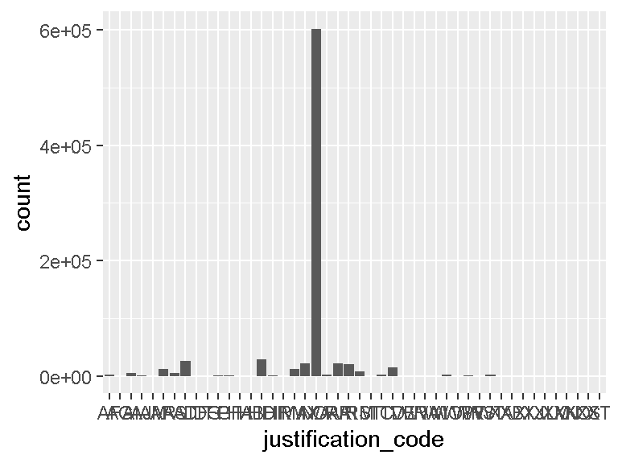

- Note that the following levels have at most five observations: "ST", "WP".

## justification_description

- The variable only takes one (non-missing) value: "nm_aerodromo_destino". The variable contains 0 % missing observations.

Report generation information:

- Created by: drinith (username: `felipe`).
- Report creation time: sex jul 22 2022 01:24:37
- Report was run from directory: `C:/Users/felipe/Documents/develop/data-mining-class/teste`
- dataMaid v1.4.1 [Pkg: 2021-10-08 from CRAN (R 4.2.1)]
- R version 4.2.0 (2022-04-22 ucrt).
- Platform: x86_64-w64-mingw32/x64 (64-bit)(Windows 10 x64 (build 22000)).
- Function call: `makeDataReport(data = bfd, output = "html", replace = TRUE)`